# Problem Set 7

2023-10-20

# Question 1e

```r
mean <- 0
n <- 100
xbar <- 0.5
sd <- 2.323
Z <- (xbar - mean)/(sd/sqrt(n))
Z
```

```
## [1] 2.152389
```

```r
pnorm(Z)
```

```
## [1] 0.9843166
```

```r
1 - pnorm(Z)
```

```
## [1] 0.01568336
```

# Question 2b

Given: n = 1000 mean = 9.06, variance = 565.2476 Standard deviation = ? Standard error = ?

```r
mean <- 9.06
sd <- sqrt(565.2476)
se <- sd/sqrt(1000)
```

95% confidence for the mean number of citations alpha = 0.05 alpha/2 = 0.025

```r
upper <- mean + qnorm(0.975,0,1) * se
lower <- mean - qnorm(0.975,0,1) * se

print(paste("The approximate 95% confidence interval for the mean number of citations is" ,upper ,"and" ,lower))
```

```
## [1] "The approximate 95% confidence interval for the mean number of citations is 10.5335587463336 and 7.58644125366642"
```

# Question 2c

Given that 460 out of 1000 articles don’t have citations This question can be turned into a bernoulli trial Probability that a article has no citation p = 460/1000 = 0.46 With 1000 trials, xbar ~ equal to p We know that sd = sqrt(xbar*(1-xbar))

```r
xbar <- 0.46
n <- 1000
sd <- sqrt(xbar*(1-xbar))
se <- sd/sqrt(n)
print(paste("standard deviation = " ,sd))
```

```
## [1] "standard deviation =  0.498397431775085"
```

```r
print(paste("standard error is = " , se))
```

```
## [1] "standard error is =  0.0157607106438764"
```

```r
upper <- xbar + qnorm(0.975) * se
lower <- xbar- qnorm(0.975) * se

print(paste("The 95% confidence interval of journal with no citation is",upper , "and" ,lower))
```

```
## [1] "The 95% confidence interval of journal with no citation is 0.490890425232755 and 0.429109574767245"
```

# Question 3

Reading the data

```r
data <- read.table("ANES2016.txt",header = TRUE)
View(data)
nrow(data)
```

```
## [1] 3600
```

Plotting the distribution of the data

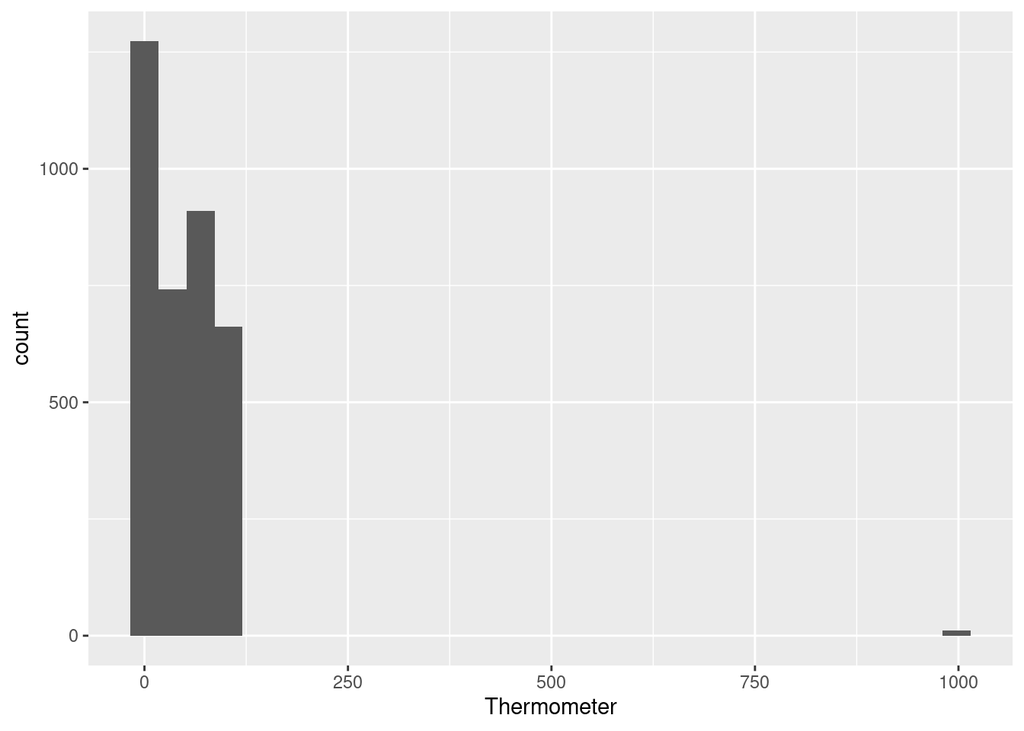

```r
library(ggplot2)
ggplot(data, aes(x = Thermometer)) + geom_histogram()
```

Plotting Trump alone

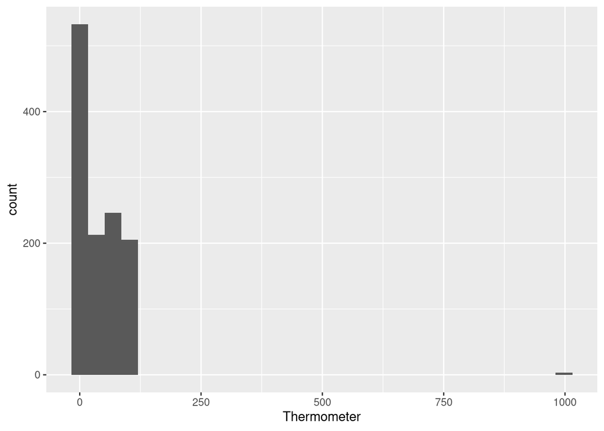

```r
trump <- subset(data,Candidate == "Trump")
ggplot(trump, aes(x = Thermometer)) + geom_histogram()
```

Plotting Clinton alone

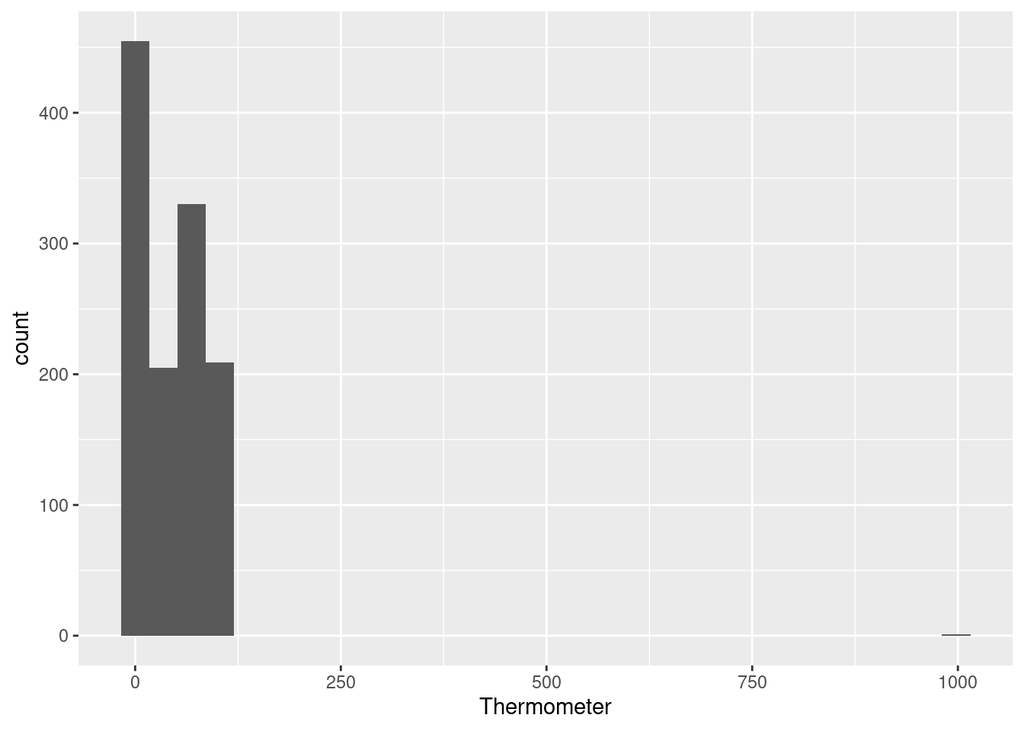

```r
clinton <- subset(data,Candidate == "Clinton")
ggplot(clinton, aes(x = Thermometer)) + geom_histogram()
```

Plotting Sanders alone

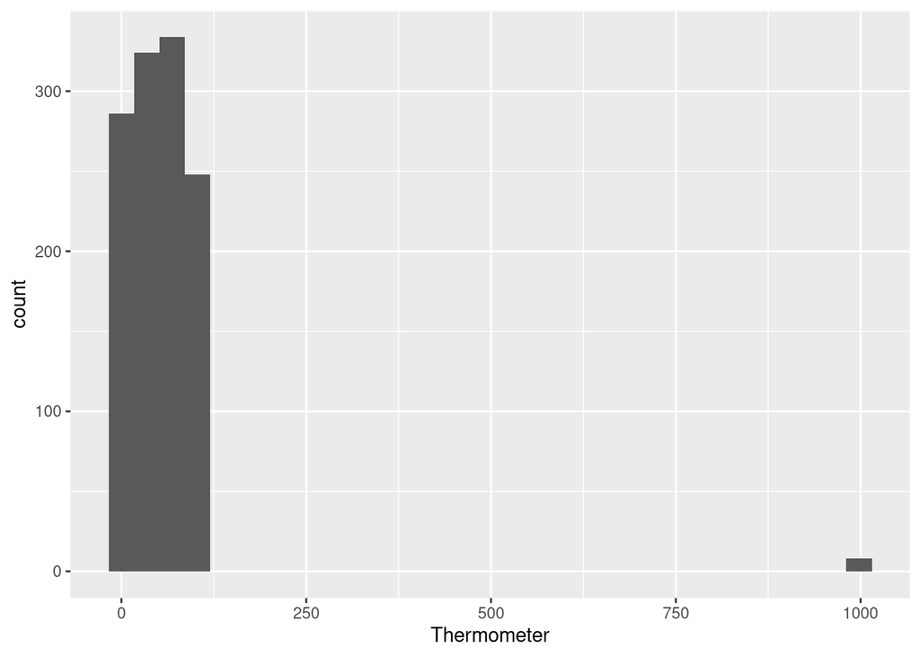

```r
sanders <- subset(data,Candidate == "Sanders")
ggplot(sanders, aes(x = Thermometer)) +geom_histogram()
```

# Question 3b

```r
temp100 <- subset(data, Thermometer <= 100)

trump <- subset(temp100, Candidate == "Trump")
meanTrump <- mean(trump$Thermometer)
sdTrump = sd(trump$Thermometer)

clinton <- subset(temp100, Candidate == "Clinton")
meanClinton <- mean(clinton$Thermometer)
sdClinton <- sd(clinton$Thermometer)

sanders <- subset(temp100, Candidate == "Sanders")
meanSanders <- mean(sanders$Thermometer)
sdSanders <- sd(sanders$Thermometer)

print(paste("Trump's Mean = ", meanTrump," Standard Deviation = ", sdTrump ))
```

```
## [1] "Trump's Mean =  38.3784461152882  Standard Deviation =  36.5289728313274"
```

```r
print(paste("Clinton's Mean = ", meanClinton," Standard Deviation = ", sdClinton ))
```

```
## [1] "Clinton's Mean =  42.9941618015012  Standard Deviation =  36.5047045603107"
```

```r
print(paste("Sanders' Mean = ", meanSanders," Standard Deviation = ", sdSanders ))
```

```
## [1] "Sanders' Mean =  50.4119127516779  Standard Deviation =  33.3909085154214"
```

# Question 3c

Find 99% confidence intervals for:

1. Trump’s mean feeling thermometer score if all adult U.S. citizens were asked in January 2016. alpha = 0.01; alpha/2 = 0.005

```r
seTrump <- sd(trump$Thermometer)/sqrt(1197)
upper <- meanTrump + qnorm(0.995) * seTrump
lower <- meanTrump - qnorm(0.995) * seTrump
print(paste("99% confidence interval of Trumps mean feeling thermometer of", meanTrump," is", upper, "and", lower))
```

```
## [1] "99% confidence interval of Trumps mean feeling thermometer of 38.3784461152882  is 41.098061346077 and 35.6588308844995"
```

2. Clinton’s mean feeling thermometer score if all adult U.S. citizens were asked in January 2016.

```r
seClint <- sd(clinton$Thermometer)/sqrt(1199)
upper <- meanClinton + qnorm(0.995) * seTrump
lower <- meanClinton - qnorm(0.995) * seTrump
print(paste("99% confidence interval of Clinton mean feeling thermometer of", meanClinton," is", upper, "and", lower))
```

```
## [1] "99% confidence interval of Clinton mean feeling thermometer of 42.9941618015012  is 45.71377703229 and 40.2745465707125"
```

3. Sanders’ mean feeling thermometer score if all adult U.S. citizens were asked in January 2016.

```r
seSanders <- sd(sanders$Thermometer)/sqrt(1192)
upper <- meanSanders + qnorm(0.995) * seTrump
lower <- meanSanders - qnorm(0.995) * seTrump
print(paste("99% confidence interval of Sanders mean feeling thermometer of", meanSanders," is", upper, "and", lower))
```

```
## [1] "99% confidence interval of Sanders mean feeling thermometer of 50.4119127516779  is 53.1315279824666 and 47.6922975208891"
```

# Question 4

Given, SD = 6 We know n = (2 * q * SD / L)^2

Given interval length = 2 feet Q value for 99% interval =

```r
qnorm(0.995)
```

```
## [1] 2.575829
```

Solving for n =

```r
n = (2 * qnorm(0.995) * 6/2)^2
n
```

```
## [1] 238.8563
```

Therefore, n = 238.85 ~ 239

# Question 5a

This can be considerd a bernoulli trial A person either supports or does not support same-sex marriage If 63% of 1009 support, then p ~ 0.63 In a bernoulli random variable, we can assume p to be same as the expected value (xbar = 0.63)

```r
xbar <- 0.63
sd <- sqrt(xbar *(1-xbar))
se <- sd / sqrt(1009)
se
```

```
## [1] 0.01519937
```

```r
upper <- xbar + qnorm(0.975) * se
lower <- xbar - qnorm(0.975) * se
print(paste("95% confidence interval for the percentage of all US adults who supports same sex marriage is", upper, "and" , lower))
```

```
## [1] "95% confidence interval for the percentage of all US adults who supports same sex marriage is 0.659790215485221 and 0.600209784514779"
```

# Question 5b

```r
confidence_level <- 0.95
length_confidence_interval <- 2

z <- qnorm((1 + confidence_level) / 2)
n <- (2 * z * sd / length_confidence_interval) ^ 2

print(paste("The sample size required will be = ", n))
```

```
## [1] "The sample size required will be =  0.8954440511038"
```